# Coursera hopkins reproducable research wk2

Thijs Durieux

31 december 2018

## R Markdown

```r
library(tidyverse)
```

# Loading and preprocessing the data

Show any code that is needed to: 1. Load the data (i.e. read.csv()) 2. Process/transform the data (if necessary) into a format suitable for your analysis

```r
fname <- 'activity.csv'
df <- read.csv(fname)
tbl <- as_tibble(df)
```

# What is mean total number of steps taken per day?

For this part of the assignment, you can ignore the missing values in the dataset. 1. Calculate the total number of steps taken per day

```r
steps_per_day <- tbl %>%
    group_by(date) %>%
    summarize(steps_per_day=sum(steps, na.rm=TRUE))
```

2. If you do not understand the difference between a histogram and a barplot, research the difference between them. Make a histogram of the total number of steps taken each day

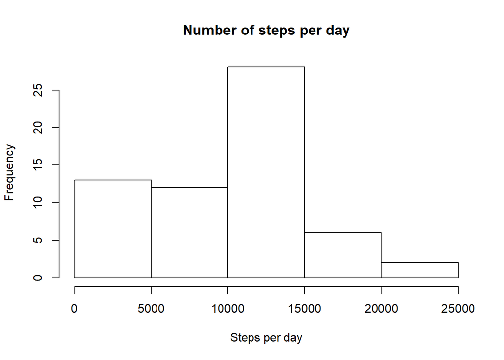

```r
hist(steps_per_day$steps_per_day, main='Number of steps per day', xlab='Steps per day', ylab='Frequency')
```

3. Calculate and report the mean and median of the total number of steps taken per day

The mean number of steps per day is:

```r
mean(steps_per_day$steps_per_day)
```

```
## [1] 9354.23
```

The meadian number of steps per day is:

```r
median(steps_per_day$steps_per_day)
```

```
## [1] 10395
```

# What is the average daily activity pattern?

Summarize the data by number of steps per time interval

```r
steps_per_interval <- tbl %>%
    group_by(interval) %>%
    summarize(steps=mean(steps, na.rm=TRUE))
```

1. Make a time series plot (i.e. type = “l”) of the 5-minute interval (x-axis) and the average number of steps taken, averaged across all days (y-axis)

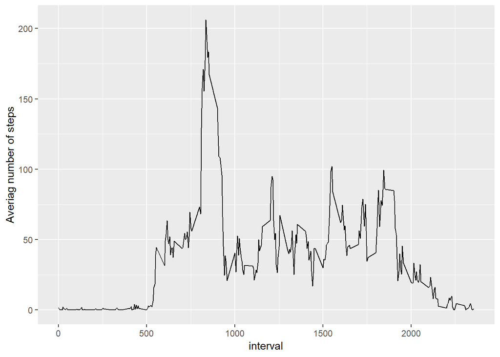

```r
ggplot(data=steps_per_interval) +
    geom_line((mapping=aes(x=interval, y=steps))) +
    xlab('interval') +
    ylab('Averiag number of steps')
```

2. Which 5-minute interval, on average across all the days in the dataset, contains the maximum number of steps?

```r
index_interval_max <- which(steps_per_interval$steps == max(steps_per_interval$steps))
steps_per_interval$interval[index_interval_max]
```

```
## [1] 835
```

Find the number of na in steps

```r
sapply(tbl, function(x) sum(is.na(x)))[1]
```

```
## steps
##  2304
```

# Imputing missing values

Note that there are a number of days/intervals where there are missing values (coded as NAs). The presence of missing days may introduce bias into some calculations or summaries of the data.

1. Calculate and report the total number of missing values in the dataset (i.e. the total number of rows with NAs)

```r
sum(is.na(tbl$steps))
```

```
## [1] 2304
```

2. Devise a strategy for filling in all of the missing values in the dataset. The strategy does not need to be sophisticated. For example, you could use the mean/median for that day, or the mean for that 5-minute interval, etc.

To fill missing values a function is made that replaces a value with the average number of steps taken in that interval.

```r
avg_steps_per_interval <- function(interval){
    steps_per_interval[match(interval, steps_per_interval$interval), ]$steps
}
```

3. Create a new dataset that is equal to the original dataset but with the missing data filled in.

```r
tbl_no_missing_data <- mutate(tbl, steps = if_else(is.na(steps), as.integer(avg_steps_per_interval(interval)), steps))
```

4. Make a histogram of the total number of steps taken each day and Calculate and report the mean and median total number of steps taken per day. Do these values differ from the estimates from the first part of the assignment? What is the impact of imputing missing data on the estimates of the total daily number of steps?

```r
steps_per_day_no_missing_data <- tbl_no_missing_data %>%
    group_by(date) %>%
    summarize(steps_per_day=sum(steps))
mean(steps_per_day_no_missing_data$steps_per_day)
```

```
## [1] 10749.77
```

```r
median(steps_per_day_no_missing_data$steps_per_day)
```

```
## [1] 10641
```

Indeed the estimates differ from the first part of the assignment. Both the mean and median increased.

Check to see if the number of missing values is indeed 0

```r
sum(is.na(tbl_no_missing_data$steps))
```

```
## [1] 0
```

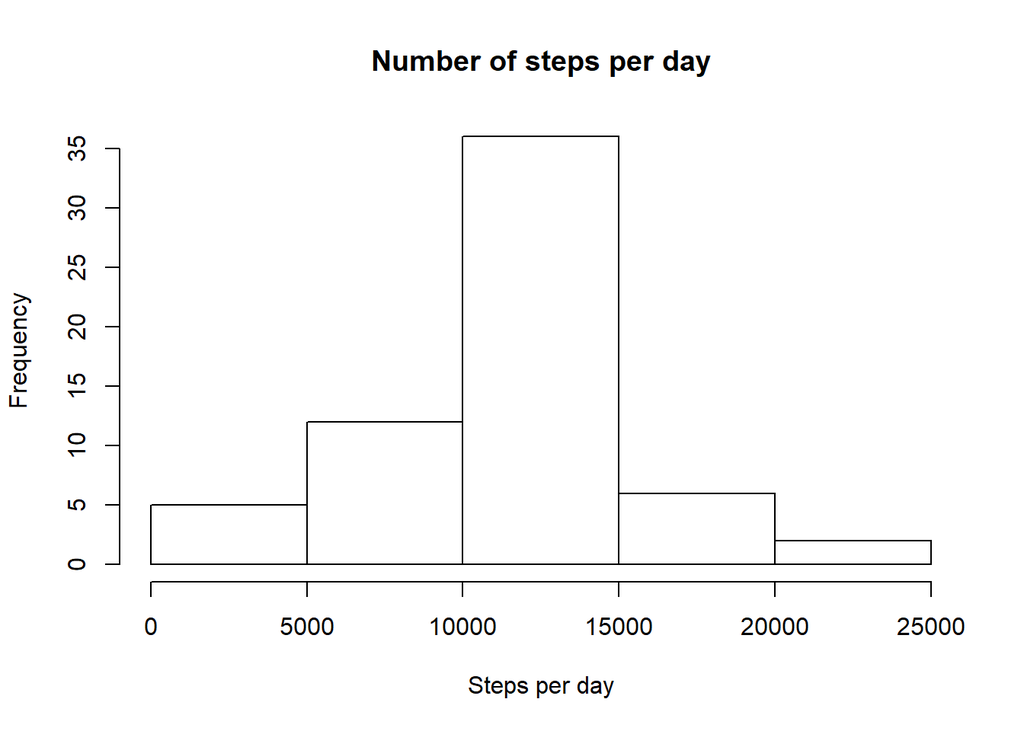

```r
hist(steps_per_day_no_missing_data$steps_per_day, main='Number of steps per day', xlab='Steps per day', ylab='Frequency')
```

# Are there differences in activity patterns between weekdays and weekends? For this part the weekdays() function may be of some help here. Use the dataset with the filled-in missing values for this part.

1. Create a new factor variable in the dataset with two levels - “weekday” and “weekend” indicating whether a given date is a weekday or weekend day.

```r
tbl_no_missing_data <- mutate(tbl_no_missing_data, weekday=as.POSIXlt(tbl_no_missing_data$date)$wday)
tbl_no_missing_data <- mutate(tbl_no_missing_data, weekday=if_else(weekday %in% c(0, 6), 0, 1))
```

2. Make a panel plot containing a time series plot (i.e. type=“l”) of the 5-minute interval (x-axis) and the average number of steps taken, averaged across all weekday days or weekend days (y-axis). See the README file in the GitHub repository to see an example of what this plot should look like using simulated data.

```r
tbl_avg_steps_per_interval_no_missing_data <- tbl_no_missing_data %>%
    group_by(interval) %>%
    summarize(steps=mean(steps, na.rm=TRUE))
```

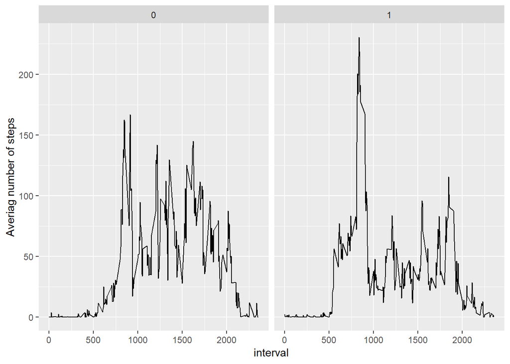

```r
ggplot(data=tbl_no_missing_data, aes(x=interval, y=steps)) +
    stat_summary(fun.y="mean", geom="line") +
    xlab('interval') +
    ylab('Averiag number of steps') +
    facet_wrap(~weekday)
```